# Projet Statistique : Analyse des Émissions des Turbines à Gaz et Maintenance Prédictive

#### # Imputattion par le KNN

```r
# Créer une copie de data sous le nom data1
data1 <- data
# Imputattion par le KNN

# Fonction pour détecter les valeurs aberrantes en utilisant l'IQR et les transformer en NA
replace_outliers_with_na <- function(column) {
  Q1 <- quantile(column, 0.25, na.rm = TRUE)
  Q3 <- quantile(column, 0.75, na.rm = TRUE)
  IQR <- Q3 - Q1
  lower_bound <- Q1 - 1.5 * IQR
  upper_bound <- Q3 + 1.5 * IQR

  # Remplacer les valeurs aberrantes par NA
  column[column < lower_bound | column > upper_bound] <- NA
  return(column)
}

# Identifier les colonnes numériques
numeric_columns <- sapply(data1, is.numeric)

# Appliquer la fonction à toutes les colonnes numériques
data_no_outliers <- data1  # Créer une copie du jeu de données

for (col_name in names(data1)[numeric_columns]) {
  data_no_outliers[[col_name]] <- replace_outliers_with_na(data1[[col_name]])
}

# Afficher le jeu de données après remplacement des valeurs aberrantes
print(data_no_outliers)
```

| AT | AP | AH | AFDP | GTEP | TIT | TAT | TEY | CDP | CO | NOX | Year |
| --- | --- | --- | --- | --- | --- | --- | --- | --- | --- | --- | --- |
| 4.5878 | 1018.7 | 83.675 | 3.5758 | 23.979 | 1086.2 | 549.83 | 134.67 | 11.898 | 0.32663000 | 81.952 | 2011 |
| 4.2932 | 1018.3 | 84.235 | 3.5709 | 23.951 | 1086.1 | 550.05 | 134.67 | 11.892 | 0.44784000 | 82.377 | 2011 |
| 3.9045 | 1018.4 | 84.858 | 3.5828 | 23.990 | 1086.5 | 550.19 | 135.10 | 12.042 | 0.45144000 | 83.776 | 2011 |
| 3.7436 | 1018.3 | 85.434 | 3.5808 | 23.911 | 1086.5 | 550.17 | 135.03 | 11.990 | 0.23107000 | 82.505 | 2011 |
| 3.7516 | 1017.8 | 85.182 | 3.5781 | 23.917 | 1085.9 | 550.00 | 134.67 | 11.910 | 0.26747000 | 82.028 | 2011 |
| 3.8858 | 1017.7 | 83.946 | 3.5824 | 23.903 | 1086.0 | 549.98 | 134.67 | 11.868 | 0.23473000 | 81.748 | 2011 |
| 3.6697 | 1018.0 | 84.114 | 3.5804 | 23.889 | 1085.9 | 550.04 | 134.68 | 11.877 | 0.44412000 | 84.592 | 2011 |
| 3.5892 | 1018.2 | 83.867 | 3.5777 | 23.876 | 1086.0 | 549.88 | 134.66 | 11.893 | 0.79996000 | 84.193 | 2011 |
| 3.7108 | 1018.5 | 84.948 | 3.6027 | 23.957 | 1086.3 | 549.98 | 134.65 | 11.870 | 0.68996000 | 83.978 | 2011 |
| 4.8281 | 1018.5 | 85.346 | 3.5158 | 23.422 | 1083.1 | 549.80 | 132.67 | 11.694 | 1.02810000 | 82.654 | 2011 |

[output cut: 990 more lines]

```r
# Compter les valeurs manquantes par colonne
colSums(is.na(data_no_outliers))
```

```
  AT   AP   AH AFDP GTEP  TIT  TAT  TEY  CDP   CO  NOX Year
   1  612  132  557    7  315 4955   33   10 2655  936    0
```

```r
# Charger le package
library(VIM)
# Imputation par KNN
data_imputed_knn <- kNN(data_no_outliers, k = 5)
data_imputed_knn <- data_imputed_knn[, !grepl("_imp$", colnames(data_imputed_knn))]

# Afficher les données après imputation




# Fonction pour calculer le pourcentage d'outliers
detecter_outliers <- function(x) {
  if (!is.numeric(x)) {
    return(NA)  # Ignorer les colonnes non numériques
  }
  Q1 <- quantile(x, 0.25)  # Premier quartile
  Q3 <- quantile(x, 0.75)  # Troisième quartile
  IQR <- Q3 - Q1  # Intervalle interquartile
  borne_inferieure <- Q1 - 1.5 * IQR
  borne_superieure <- Q3 + 1.5 * IQR
  outliers <- sum(x < borne_inferieure | x > borne_superieure)
  total_valeurs <- length(x)
  return(outliers / total_valeurs * 100)  # Pourcentage d'outliers
}


# Appliquer la fonction à chaque colonne de la dataframe
pourcentage_outliers <- sapply(data_imputed_knn, detecter_outliers)

# Résultat
print(pourcentage_outliers)
```

```
         AT          AP          AH        AFDP        GTEP         TIT         TAT         TEY         CDP          CO         NOX        Year
0.000000000 0.149729126 0.002722348 0.087115128 0.000000000 0.000000000 0.413796858 0.000000000 0.000000000 2.578063322 0.049002260 0.000000000
```

#===================================================== Regression pour CO ================================================== ### Modèle de régression multiple

Notre data traité maintenant est “data_imputed_knn”

```r
# Modèle de régression multiple avec toutes les variables après traitement des outliers
model3 <- lm(CO ~ AT + AP  + AH + AFDP + TEY + TIT + GTEP + CDP + TAT , data = data_imputed_knn)
# Résumé du modèle
summary(model3)
```

```
Call:
lm(formula = CO ~ AT + AP + AH + AFDP + TEY + TIT + GTEP + CDP +
    TAT, data = data_imputed_knn)

Residuals:
    Min      1Q  Median      3Q     Max
-5.1689 -0.4831 -0.0342  0.4888  4.2251

Coefficients:
              Estimate Std. Error t value Pr(>|t|)
(Intercept) 60.6697466  1.4088464  43.063  < 2e-16 ***
AT          -0.0215140  0.0016568 -12.985  < 2e-16 ***
AP          -0.0010109  0.0008935  -1.131  0.25794
AH          -0.0060073  0.0003882 -15.476  < 2e-16 ***
AFDP        -0.0163035  0.0093476  -1.744  0.08115 .
TEY         -0.0526131  0.0043935 -11.975  < 2e-16 ***
TIT         -0.0522925  0.0014138 -36.986  < 2e-16 ***
GTEP         0.1441819  0.0057966  24.874  < 2e-16 ***
CDP          0.1706679  0.0585774   2.914  0.00358 **
TAT          0.0021456  0.0023195   0.925  0.35496
---
Signif. codes:  0 ‘***’ 0.001 ‘**’ 0.01 ‘*’ 0.05 ‘.’ 0.1 ‘ ’ 1

Residual standard error: 0.8561 on 36723 degrees of freedom
Multiple R-squared:  0.5724,    Adjusted R-squared:  0.5723
F-statistic:  5462 on 9 and 36723 DF,  p-value: < 2.2e-16
```

Résultat : Adjusted R-squared: 0.5723, indiquant que le modèle explique 57.23% de la variance des émissions de CO. Les variables non significatives, comme AP (p > 0.05) et TAT, seront éliminées pour améliorer le modèle.

#### Amélioration du modèle

```r
# Modèle 4 : Suppression des variables AP et TAT
model4 <- lm(CO ~ AT  + AH  + TEY + TIT + GTEP + AFDP + CDP, data = data_imputed_knn)
# Résumé du modèle
summary(model4)
```

```
Call:
lm(formula = CO ~ AT + AH + TEY + TIT + GTEP + AFDP + CDP, data = data_imputed_knn)

Residuals:
    Min      1Q  Median      3Q     Max
-5.1965 -0.4826 -0.0350  0.4886  4.2357

Coefficients:
              Estimate Std. Error t value Pr(>|t|)
(Intercept) 60.4190893  1.0888507  55.489  < 2e-16 ***
AT          -0.0206510  0.0014887 -13.872  < 2e-16 ***
AH          -0.0059042  0.0003736 -15.802  < 2e-16 ***
TEY         -0.0509323  0.0042010 -12.124  < 2e-16 ***
TIT         -0.0516932  0.0011207 -46.126  < 2e-16 ***
GTEP         0.1453022  0.0057384  25.321  < 2e-16 ***
AFDP        -0.0172627  0.0092941  -1.857  0.06326 .
CDP          0.1275289  0.0494280   2.580  0.00988 **
---
Signif. codes:  0 ‘***’ 0.001 ‘**’ 0.01 ‘*’ 0.05 ‘.’ 0.1 ‘ ’ 1

Residual standard error: 0.8561 on 36725 degrees of freedom
Multiple R-squared:  0.5724,    Adjusted R-squared:  0.5723
F-statistic:  7022 on 7 and 36725 DF,  p-value: < 2.2e-16
```

- Résultat : Adjusted R-squared reste à 0.5723. Cela confirme que l’exclusion de AP et TAT n’a pas affecté la capacité explicative du modèle.

##### Affinage du modèle

```r
# Modèle 5 : Suppression supplémentaire de AFDP en raison de son manque de significativité
model5 <- lm(CO ~ AT  + AH  + TEY + TIT + GTEP + CDP, data = data_imputed_knn)
summary(model5)
```

```
Call:
lm(formula = CO ~ AT + AH + TEY + TIT + GTEP + CDP, data = data_imputed_knn)

Residuals:
    Min      1Q  Median      3Q     Max
-5.1958 -0.4827 -0.0358  0.4883  4.2142

Coefficients:
             Estimate Std. Error t value Pr(>|t|)
(Intercept) 60.726493   1.076235  56.425   <2e-16 ***
AT          -0.020913   0.001482 -14.111   <2e-16 ***
AH          -0.006014   0.000369 -16.299   <2e-16 ***
TEY         -0.050013   0.004172 -11.988   <2e-16 ***
TIT         -0.051926   0.001114 -46.625   <2e-16 ***
GTEP         0.145989   0.005727  25.493   <2e-16 ***
CDP          0.106792   0.048152   2.218   0.0266 *
---
Signif. codes:  0 ‘***’ 0.001 ‘**’ 0.01 ‘*’ 0.05 ‘.’ 0.1 ‘ ’ 1

Residual standard error: 0.8562 on 36726 degrees of freedom
Multiple R-squared:  0.5723,    Adjusted R-squared:  0.5722
F-statistic:  8191 on 6 and 36726 DF,  p-value: < 2.2e-16
```

- Résultat : Adjusted R-squared est légèrement réduit à 0.5722. Les variables restantes expliquent 57.22% de la variance des émissions de CO. Après avoir supprimé la variable AFDP en raison de son manque de significativité, le modèle 5 explique 57.22% de la variance des émissions de CO (Adjusted R-squared = 0.5722), légèrement supérieur à la variance expliquée avant traitement des outliers (56.33%).  
  Cette amélioration reflète l’impact positif du traitement des valeurs aberrantes sur la qualité du modèle.

#===================================================== Regression pour NOX ================================================== ### Modèle de régression multiple

```r
# Modèle de régression multiple avec toutes les variables après traitement des outliers
model3N <- lm(NOX ~ AT + AP  + AH + AFDP + TEY + TIT + GTEP + CDP + TAT , data = data_imputed_knn)
# Résumé du modèle
summary(model3N)
```

```
Call:
lm(formula = NOX ~ AT + AP + AH + AFDP + TEY + TIT + GTEP + CDP +
    TAT, data = data_imputed_knn)

Residuals:
    Min      1Q  Median      3Q     Max
-35.202  -3.978   0.079   3.723  59.247

Coefficients:
              Estimate Std. Error  t value Pr(>|t|)
(Intercept) 102.549665  11.091382    9.246   <2e-16 ***
AT           -1.708903   0.013044 -131.014   <2e-16 ***
AP           -0.206041   0.007034  -29.290   <2e-16 ***
AH           -0.206141   0.003056  -67.455   <2e-16 ***
AFDP          1.332904   0.073591   18.112   <2e-16 ***
TEY          -1.549533   0.034588  -44.799   <2e-16 ***
TIT           1.334170   0.011131  119.864   <2e-16 ***
GTEP         -0.016873   0.045634   -0.370    0.712
CDP          -4.786564   0.461161  -10.379   <2e-16 ***
TAT          -1.765247   0.018260  -96.671   <2e-16 ***
---
Signif. codes:  0 ‘***’ 0.001 ‘**’ 0.01 ‘*’ 0.05 ‘.’ 0.1 ‘ ’ 1

Residual standard error: 6.74 on 36723 degrees of freedom
Multiple R-squared:  0.5777,    Adjusted R-squared:  0.5776
F-statistic:  5582 on 9 and 36723 DF,  p-value: < 2.2e-16
```

Résultat : Adjusted R-squared: 0.5777, indiquant que le modèle explique 57.77% de la variance des émissions de NOX. Les variables non significatives, comme GTEP (p > 0.05) , sera éliminée pour améliorer le modèle.

#### Amélioration du modèle

```r
# Modèle 4 : Suppression des variables AP et TAT
model4N <- lm(NOX ~ AT  + AH  + TEY + TIT + AP + TAT + AFDP + CDP, data = data_imputed_knn)
# Résumé du modèle
summary(model4N)
```

```
Call:
lm(formula = NOX ~ AT + AH + TEY + TIT + AP + TAT + AFDP + CDP,
    data = data_imputed_knn)

Residuals:
    Min      1Q  Median      3Q     Max
-35.194  -3.978   0.078   3.724  59.258

Coefficients:
              Estimate Std. Error  t value Pr(>|t|)
(Intercept) 101.529711  10.742759    9.451   <2e-16 ***
AT           -1.710035   0.012679 -134.869   <2e-16 ***
AH           -0.205965   0.003019  -68.230   <2e-16 ***
TEY          -1.552399   0.033708  -46.055   <2e-16 ***
TIT           1.335436   0.010591  126.094   <2e-16 ***
AP           -0.205700   0.006974  -29.497   <2e-16 ***
TAT          -1.765659   0.018226  -96.875   <2e-16 ***
AFDP          1.334440   0.073473   18.162   <2e-16 ***
CDP          -4.829500   0.446297  -10.821   <2e-16 ***
---
Signif. codes:  0 ‘***’ 0.001 ‘**’ 0.01 ‘*’ 0.05 ‘.’ 0.1 ‘ ’ 1

Residual standard error: 6.74 on 36724 degrees of freedom
Multiple R-squared:  0.5777,    Adjusted R-squared:  0.5776
F-statistic:  6280 on 8 and 36724 DF,  p-value: < 2.2e-16
```

- Résultat : Adjusted R-squared reste à 0.5777. Cela confirme que l’exclusion de GTEP n’a pas affecté la capacité explicative du modèle.

#============================================================ Test ANOVA =======================================================

### ======================= Test ANOVA CO

Application du test ANOVA sur les modèles pour évaluer la significativité des variables pour le CO

```r
anova_results3 <- anova(model3)
anova_results3
```

```
Analysis of Variance Table

Response: CO
             Df  Sum Sq Mean Sq    F value    Pr(>F)
AT            1  1160.9  1160.9  1583.8317 < 2.2e-16 ***
AP            1   120.7   120.7   164.6751 < 2.2e-16 ***
AH            1    56.7    56.7    77.3199 < 2.2e-16 ***
AFDP          1 16007.8 16007.8 21839.2006 < 2.2e-16 ***
TEY           1 13614.0 13614.0 18573.3334 < 2.2e-16 ***
TIT           1  4547.1  4547.1  6203.5395 < 2.2e-16 ***
GTEP          1   515.8   515.8   703.6635 < 2.2e-16 ***
CDP           1     5.7     5.7     7.7926  0.005249 **
TAT           1     0.6     0.6     0.8557  0.354959
Residuals 36723 26917.4     0.7
---
Signif. codes:  0 ‘***’ 0.001 ‘**’ 0.01 ‘*’ 0.05 ‘.’ 0.1 ‘ ’ 1
```

```r
anova_results4 <- anova(model4)
anova_results4
```

```
Analysis of Variance Table

Response: CO
             Df  Sum Sq Mean Sq    F value    Pr(>F)
AT            1  1160.9  1160.9  1583.8314 < 2.2e-16 ***
AH            1   103.5   103.5   141.1708 < 2.2e-16 ***
TEY           1 29680.1 29680.1 40492.0965 < 2.2e-16 ***
TIT           1  4559.2  4559.2  6220.0478 < 2.2e-16 ***
GTEP          1   518.0   518.0   706.6780 < 2.2e-16 ***
AFDP          1     1.3     1.3     1.7120  0.190733
CDP           1     4.9     4.9     6.6569  0.009881 **
Residuals 36725 26918.8     0.7
---
Signif. codes:  0 ‘***’ 0.001 ‘**’ 0.01 ‘*’ 0.05 ‘.’ 0.1 ‘ ’ 1
```

Résultat :  
- **AFDP** n’est plus significative (p = 0.191), ce qui indique que son effet est négligeable lorsqu’elle est combinée avec les autres variables dans ce modèle.  
- Les variables **AT**, **AH**, **TEY**, **TIT**, et **GTEP** restent très significatives (p < 0.001), tout comme dans le modèle précédent (**model3**).  
- **CDP** reste significative (p = 0.0099), bien que son impact soit relativement faible.  
- La contribution de **TEY** (F = 40,492) et **TIT** (F = 6,220) demeure majeure, soulignant qu’elles expliquent une grande partie de la variance des émissions de **CO**.

### ======================= Test ANOVA NOX

```r
anova_results3N <- anova(model3N)
anova_results3N
```

```
Analysis of Variance Table

Response: NOX
             Df  Sum Sq Mean Sq    F value    Pr(>F)
AT            1 1275364 1275364 28073.4526 < 2.2e-16 ***
AP            1    5814    5814   127.9745 < 2.2e-16 ***
AH            1   79700   79700  1754.3643 < 2.2e-16 ***
AFDP          1     855     855    18.8098 1.448e-05 ***
TEY           1  152322  152322  3352.9250 < 2.2e-16 ***
TIT           1  284783  284783  6268.6787 < 2.2e-16 ***
GTEP          1     360     360     7.9292  0.004867 **
CDP           1   58491   58491  1287.5062 < 2.2e-16 ***
TAT           1  424553  424553  9345.3100 < 2.2e-16 ***
Residuals 36723 1668309      45
---
Signif. codes:  0 ‘***’ 0.001 ‘**’ 0.01 ‘*’ 0.05 ‘.’ 0.1 ‘ ’ 1
```

```r
anova_results4N <- anova(model4N)
anova_results4N
```

```
Analysis of Variance Table

Response: NOX
             Df  Sum Sq Mean Sq  F value    Pr(>F)
AT            1 1275364 1275364 28074.11 < 2.2e-16 ***
AH            1   63495   63495  1397.69 < 2.2e-16 ***
TEY           1   87397   87397  1923.84 < 2.2e-16 ***
TIT           1  288305  288305  6346.35 < 2.2e-16 ***
AP            1   22123   22123   486.99 < 2.2e-16 ***
TAT           1  527279  527279 11606.80 < 2.2e-16 ***
AFDP          1   12952   12952   285.12 < 2.2e-16 ***
CDP           1    5320    5320   117.10 < 2.2e-16 ***
Residuals 36724 1668315      45
---
Signif. codes:  0 ‘***’ 0.001 ‘**’ 0.01 ‘*’ 0.05 ‘.’ 0.1 ‘ ’ 1
```

#========================================== Test Normalité pour CO ==========================================

#### Vérification de la Normalité des Résidus du Modèle 5 pour CO

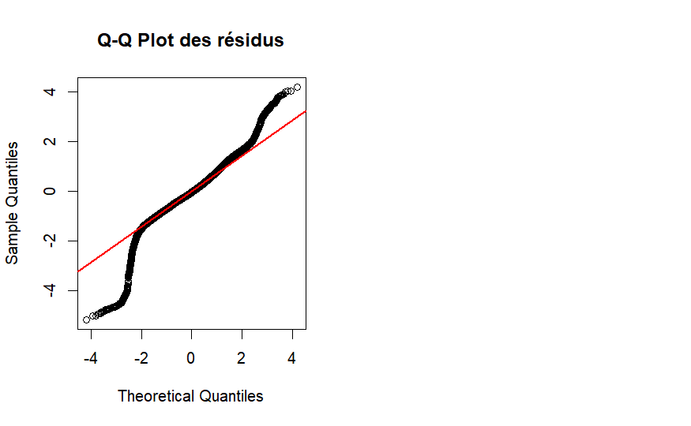

```r
# Diviser l'affichage en 2 colonnes pour afficher les deux graphiques
par(mfrow = c(1, 2))

# Extraire les résidus du modèle
residuals_model <- residuals(model5)
valeurs_predites <- fitted(model5)

# 1. Q-Q plot pour vérifier la normalité des résidus
qqnorm(residuals_model, main = "Q-Q Plot des résidus")
qqline(residuals_model, col = "red", lwd = 2)  # Ajouter une ligne de référence
```

#### Histogramme des résidus

```r
hist(residuals_model, breaks = 30, main = "Histogramme des résidus avec courbe normale",
     xlab = "Valeurs des résidus", col = "lightblue", freq = FALSE)

# Ajouter la courbe de densité empirique des résidus
lines(density(residuals_model), col = "blue", lwd = 2)
```

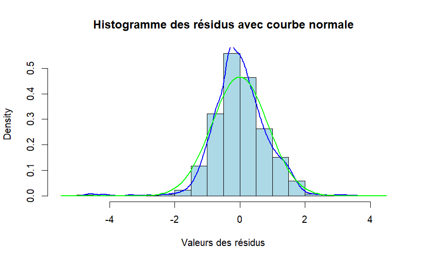

```r
# Ajouter la courbe théorique de la loi normale
curve(dnorm(x, mean = mean(residuals_model), sd = sd(residuals_model)),
      col = "green", lwd = 2, add = TRUE)
```

```r
NA
NA
```

#### Test d’Hétéroscédasticité

Vérification de l’hétéroscédasticité par l’examen des résidus

```r
#
plot(residuals_model, valeurs_predites,
     main = "Heteroscedasticity Test (Residuals on X-axis)",
     xlab = "Résidus",
     ylab = "Valeurs prédites",
     pch = 20,
     col = "blue")

# Ajouter une ligne verticale à 0 pour référence
abline(v = 0, col = "red", lwd = 2)
```

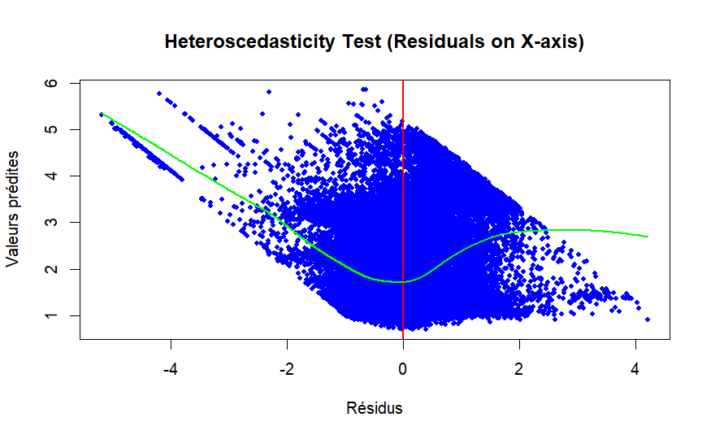

```r
# Ajouter une courbe de tendance pour observer les patterns éventuels
lines(lowess(residuals_model, valeurs_predites), col = "green", lwd = 2)
```

```r
# Résultat : Une courbe de tendance est ajoutée pour détecter des motifs éventuels dans les résidus.
# Une absence d'hétéroscédasticité renforcerait la robustesse des résultats.
```

#==================================================

#### Vérification de la Normalité des Résidus du Modèle 4N pour NOX

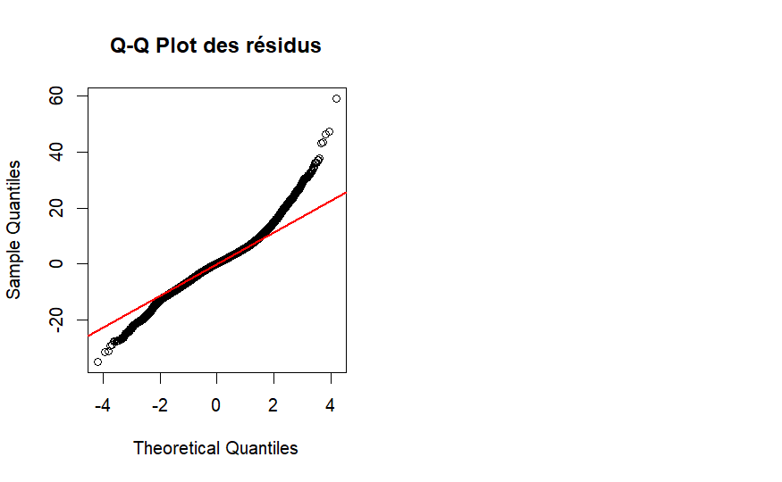

```r
# Diviser l'affichage en 2 colonnes pour afficher les deux graphiques
par(mfrow = c(1, 2))

# Extraire les résidus du modèle
residuals_modelN <- residuals(model4N)
valeurs_preditesN <- fitted(model4N)

# 1. Q-Q plot pour vérifier la normalité des résidus
qqnorm(residuals_modelN, main = "Q-Q Plot des résidus")
qqline(residuals_modelN, col = "red", lwd = 2)  # Ajouter une ligne de référence
```

#### Histogramme des résidus

```r
hist(residuals_modelN, breaks = 30, main = "Histogramme des résidus avec courbe normale",
     xlab = "Valeurs des résidus", col = "lightblue", freq = FALSE)

# Ajouter la courbe de densité empirique des résidus
lines(density(residuals_modelN), col = "blue", lwd = 2)
```

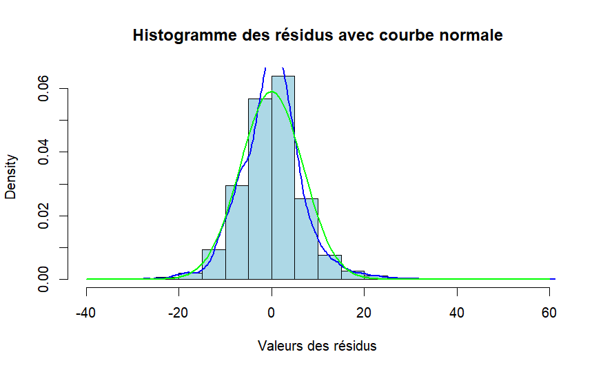

```r
# Ajouter la courbe théorique de la loi normale
curve(dnorm(x, mean = mean(residuals_modelN), sd = sd(residuals_modelN)),
      col = "green", lwd = 2, add = TRUE)
```

```r
NA
NA
```

#### Test d’Hétéroscédasticité

Vérification de l’hétéroscédasticité par l’examen des résidus

```r
#
plot(residuals_modelN, valeurs_preditesN,
     main = "Heteroscedasticity Test (Residuals on X-axis)",
     xlab = "Résidus",
     ylab = "Valeurs prédites",
     pch = 20,
     col = "blue")

# Ajouter une ligne verticale à 0 pour référence
abline(v = 0, col = "red", lwd = 2)
```

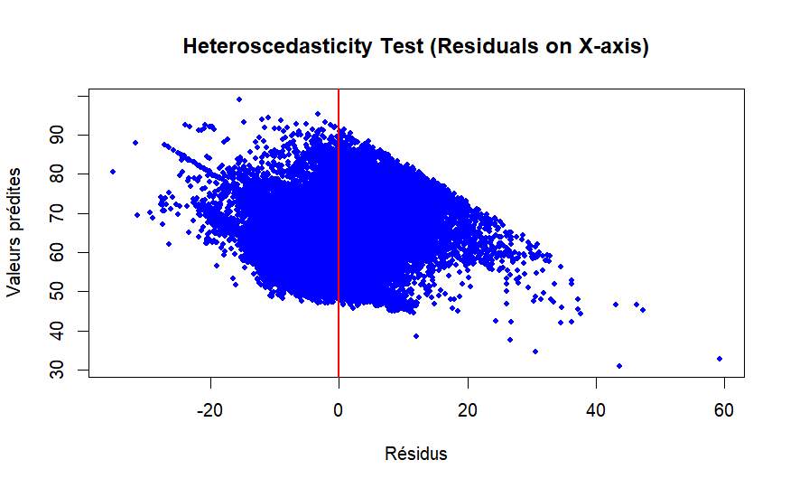

```r
# Ajouter une courbe de tendance pour observer les patterns éventuels
lines(lowess(residuals_modelN, valeurs_predites), col = "green", lwd = 2)
```

```r
# Résultat : Une courbe de tendance est ajoutée pour détecter des motifs éventuels dans les résidus.
# Une absence d'hétéroscédasticité renforcerait la robustesse des résultats.
```

#======================================================================================================================================================== # ANALYSE DATASET 2020  
#======================================================================================================================================================== # Analyse du Dataset AI4I 2020 : Maintenance Prédictive

Dans cette section, nous analysons le dataset AI4I 2020 sur la maintenance prédictive. L’objectif principal est d’explorer les relations entre les défaillances des machines (Machine_failure), la qualité des produits (Type : High, Medium, Low), et d’autres variables pertinentes telles que la vitesse de rotation (Rotational_speed).

#### Chargement des Données et Exploration Initiale

```r
# Chargement du dataset
df_2020 <- read.csv("ai4i2020.csv")

# Aperçu des premières lignes
head(df_2020)
```

|  | UDI | Product.ID | Type | Air.temperature..K. | Process.temperature..K. | Rotational.speed..rpm. | Torque..Nm. | Tool.wear..min. | Machine.failure | TWF | HDF | PWF | OSF | RNF |
| --- | --- | --- | --- | --- | --- | --- | --- | --- | --- | --- | --- | --- | --- | --- |
| 1 | 1 | M14860 | M | 298.1 | 308.6 | 1551 | 42.8 | 0 | 0 | 0 | 0 | 0 | 0 | 0 |
| 2 | 2 | L47181 | L | 298.2 | 308.7 | 1408 | 46.3 | 3 | 0 | 0 | 0 | 0 | 0 | 0 |
| 3 | 3 | L47182 | L | 298.1 | 308.5 | 1498 | 49.4 | 5 | 0 | 0 | 0 | 0 | 0 | 0 |
| 4 | 4 | L47183 | L | 298.2 | 308.6 | 1433 | 39.5 | 7 | 0 | 0 | 0 | 0 | 0 | 0 |
| 5 | 5 | L47184 | L | 298.2 | 308.7 | 1408 | 40.0 | 9 | 0 | 0 | 0 | 0 | 0 | 0 |
| 6 | 6 | M14865 | M | 298.1 | 308.6 | 1425 | 41.9 | 11 | 0 | 0 | 0 | 0 | 0 | 0 |

```r
# Vérification des valeurs manquantes
print(paste("Valeurs Manquantes :", sum(is.na(df_2020$Machine.failure))))  # Résultat attendu : 0 (pas de valeurs manquantes)
```

```
[1] "Valeurs Manquantes : 0"
```

```r
# Vérification des niveaux de Machine_failure
print(paste("Niveaux de Machine_failure :", toString(unique(df_2020$Machine.failure))))
```

```
[1] "Niveaux de Machine_failure : 0, 1"
```

```r
# Obtenir les dimensions du dataset
dataset_shape <- dim(df_2020)

# Afficher le résultat
cat("Le dataset contient", dataset_shape[1], "lignes et", dataset_shape[2], "colonnes.\n")
```

```
Le dataset contient 10000 lignes et 14 colonnes.
```

#### Test du Chi-Carré : Relation entre Type et Machine_failure

- H0 (hypothèse nulle) : Les variables Type et Machine_failure sont indépendantes, c’est-à-dire que la qualité du produit (Type) n’a pas d’effet sur la probabilité de défaillance de la machine (Machine_failure).
- H1 (hypothèse alternative) : Les variables Type et Machine_failure sont dépendantes, c’est-à-dire que la qualité du produit est associée à la probabilité de défaillance de la machine.

```r
# Créer la table de contingence
table_contingence <- table(df_2020$Type, df_2020$Machine.failure)
cat("Table de contingence :\n")
```

```
Table de contingence :
```

```r
print(table_contingence)
```

```
       0    1
  H  982   21
  L 5765  235
  M 2914   83
```

```r
# Test du chi-carré
chi_result <- chisq.test(table_contingence)
cat("Résultat du test chi-carré :\n")
```

```
Résultat du test chi-carré :
```

```r
print(chi_result)
```

```
    Pearson's Chi-squared test

data:  table_contingence
X-squared = 13.752, df = 2, p-value = 0.001032
```

La p-value obtenue est 0.001032, qui est bien inférieure au seuil de signification typique de 0.05. Cela signifie que les résultats sont statistiquement significatifs, et nous pouvons rejeter l’hypothèse nulle (H0). En d’autres termes, il existe une relation significative entre la qualité du produit (Type) et les défaillances des machines (Machine_failure).

#### # L’indice de Cramer’s

Le test du chi-carré indique qu’il existe une relation significative, mais il ne mesure pas l’intensité de cette relation. Pour cela, vous pouvez calculer l’indice de Cramer’s

```r
library(DescTools)
cramer_v <- CramerV(table_contingence)
print(cramer_v)
```

```
[1] 0.03708331
```

L’indice de Cramer V, nous indique que l’association entre ces variables est très faible (0.037), bien qu’elle soit significative. Cela suggère que d’autres facteurs, non inclus dans cette analyse, influencent davantage les défaillances des machines.

#### ANOVA : Relation entre Rotational_speed et Type

Nous avons utilisé le test de Shapiro-Wilk pour vérifier la normalité des données avant d’appliquer l’ANOVA, car ce test permet de déterminer si les données suivent une distribution normale. Cela est crucial car l’ANOVA repose sur l’hypothèse de normalité des groupes.

Le test de Shapiro-Wilk ne peut pas être appliqué à des échantillons de taille supérieure à 5000. Par conséquent, nous avons sous-échantillonné chaque groupe à 1000 observations pour respecter cette contrainte et effectuer le test de normalité de manière appropriée.

```r
library(dplyr)
# Filtrer les données pour chaque niveau de qualité de produit et sous-échantillonner 1000 lignes
high_quality <- df_2020 %>% filter(Type == "H") %>% sample_n(1000) %>% pull(Rotational.speed..rpm.)
low_quality <- df_2020 %>% filter(Type == "L") %>% sample_n(1000) %>% pull(Rotational.speed..rpm.)
medium_quality <- df_2020 %>% filter(Type == "M") %>% sample_n(1000) %>% pull(Rotational.speed..rpm.)

# Test de normalité (Shapiro-Wilk) pour chaque sous-échantillon
test_high <- shapiro.test(high_quality)
test_low <- shapiro.test(low_quality)
test_medium <- shapiro.test(medium_quality)

# Créer un tableau avec les résultats
normality_results <- data.frame(
  Product_Quality = c("High", "Low", "Medium"),
  Statistic = c(test_high$statistic, test_low$statistic, test_medium$statistic),
  p_value = c(test_high$p.value, test_low$p.value, test_medium$p.value)
)
# Afficher les résultats
print(normality_results)
```

| Product_Quality | Statistic | p_value |
| --- | --- | --- |
| High | 0.8626266 | 1.106055e-28 |
| Low | 0.8916760 | 6.533871e-26 |
| Medium | 0.8937427 | 1.079830e-25 |

```r
# Test de Kruskal-Wallis pour comparer la vitesse de rotation entre les groupes
kruskal_test <- kruskal.test(Rotational.speed..rpm. ~ Type, data = df_2020)

# Afficher les résultats du test
print(kruskal_test)
```

```
    Kruskal-Wallis rank sum test

data:  Rotational.speed..rpm. by Type
Kruskal-Wallis chi-squared = 0.2479, df = 2, p-value = 0.8834
```

Les résultats montrent que les données pour chaque groupe (High, Low, Medium) ne suivent pas une distribution normale (p-value très faible dans les tests de Shapiro-Wilk). Le test de Kruskal-Wallis indique qu’il n’y a pas de différence significative entre les groupes en termes de vitesse de rotation (p-value = 0.8834).

Étant donné que les résultats du test de Shapiro-Wilk montrent que les données ne suivent pas une distribution normale pour les trois groupes (p-value très faible), il n’est pas recommandé de passer à l’ANOVA, car cette méthode suppose une normalité des résidus.